[figure not shown]

UNIVERSIDAD NACIONAL TORIBIO RODRÍGUEZ DE MENDOZA DE AMAZONAS Facultad de Ingeniería y Ciencias Agrarias · Escuela Profesional de Ingeniería Agronómica

[figure not shown]

# Boro y potasio en piña Golden MD-2

Reanálisis con submuestreo y enfoque multivariado

Autor/a

Gerson Valqui Tauca

Fecha de publicación

22 de octubre de 2026

**Estudiante:** Gerson Valqui Tauca

**Escuela:** Ingeniería Agronómica

**Ciclo:** VIII

**Curso:** Programación y Análisis de Datos

**Trabajo:** Individual

**Fecha:** 22 de octubre de 2026

**Ver código R: lectura y unión de tablas**

```r
library(agricolae); library(dplyr); library(tidyr); library(ggplot2); library(knitr)

parcelas <- read.csv("datos/parcelas.csv")   # 28 unidades experimentales
plantas  <- read.csv("datos/plantas.csv")    # 112 plantas (submuestras)

orden <- c("T0 Testigo", "B100-K100", "B100-K150", "B100-K200",
           "B150-K100", "B150-K150", "B150-K200")
vars <- c(Ancho_fruto_cm = "Ancho (cm)", Longitud_fruto_cm = "Longitud (cm)",
          Peso_fruto_kg = "Peso (kg)", Longitud_corona_cm = "Corona (cm)", Brix = "°Brix")

# Unión de las dos tablas por la clave Parcela
d <- plantas |>
  left_join(parcelas |> select(Parcela:Potasio_ml), by = "Parcela") |>
  mutate(Bloque = factor(Bloque), Parcela = factor(Parcela),
         Tratamiento = factor(Tratamiento, levels = orden),
         Tipo = factor(Tipo, levels = c("Testigo", "Factorial")),
         Boro = factor(Boro_ml), Potasio = factor(Potasio_ml))
```

## Base de datos

La hoja original tenía cinco tablas apiladas, celdas de dosis vacías y encabezados en dos filas. Se reorganizó como **base relacional**: dos tablas unidas por la columna `Parcela`.

**Ver código R**

```r
kable(head(parcelas, 7), caption = "Tabla 1. Unidades experimentales (7 de 28 filas)")
```

Tabla 1. Unidades experimentales (7 de 28 filas)

| Parcela | Bloque | Tratamiento | Tipo | Boro_ml | Potasio_ml | n_plantas | Ancho_fruto_cm_media | Longitud_fruto_cm_media | Peso_fruto_kg_media | Longitud_corona_cm_media | Brix_media |
| --- | --- | --- | --- | --- | --- | --- | --- | --- | --- | --- | --- |
| 1 | I | T0 Testigo | Testigo | 0 | 0 | 4 | 13.900 | 17.150 | 2.175 | 23.525 | 14.000 |
| 2 | II | T0 Testigo | Testigo | 0 | 0 | 4 | 13.575 | 16.600 | 2.025 | 23.925 | 14.250 |
| 3 | III | T0 Testigo | Testigo | 0 | 0 | 4 | 13.825 | 16.300 | 2.025 | 23.775 | 14.225 |
| 4 | IV | T0 Testigo | Testigo | 0 | 0 | 4 | 13.000 | 15.625 | 1.725 | 20.000 | 14.025 |
| 5 | I | B100-K100 | Factorial | 100 | 100 | 4 | 12.675 | 14.700 | 2.000 | 21.650 | 13.650 |
| 6 | II | B100-K100 | Factorial | 100 | 100 | 4 | 12.650 | 15.650 | 1.875 | 23.175 | 14.000 |
| 7 | III | B100-K100 | Factorial | 100 | 100 | 4 | 13.850 | 18.200 | 2.625 | 24.025 | 14.125 |

**Ver código R**

```r
kable(head(plantas, 8), caption = "Tabla 2. Plantas evaluadas (8 de 112 filas)")
```

Tabla 2. Plantas evaluadas (8 de 112 filas)

| Parcela | Planta | Ancho_fruto_cm | Longitud_fruto_cm | Peso_fruto_kg | Longitud_corona_cm | Brix |
| --- | --- | --- | --- | --- | --- | --- |
| 1 | 1 | 14.5 | 17.4 | 2.5 | 22.4 | 15 |
| 1 | 2 | 13.5 | 16.0 | 1.9 | 25.6 | 14 |
| 1 | 3 | 13.6 | 17.7 | 2.1 | 24.3 | 13 |
| 1 | 4 | 14.0 | 17.5 | 2.2 | 21.8 | 14 |
| 2 | 1 | 14.0 | 16.7 | 2.4 | 30.0 | 14 |
| 2 | 2 | 13.3 | 16.0 | 1.7 | 23.4 | 14 |
| 2 | 3 | 13.6 | 17.1 | 2.1 | 22.3 | 14 |
| 2 | 4 | 13.4 | 16.6 | 1.9 | 20.0 | 15 |

Descargar base de datos (Excel)

## Modelo estadístico

DBCA con submuestreo; arreglo factorial 2 (boro) × 3 (potasio) + testigo; 4 bloques; 4 plantas por parcela.

$$Y_{ijk} = \mu + \beta_j + \tau_i + \varepsilon_{ij} + \delta_{ijk}$$

| Término | Significado |
| --- | --- |
| $Y_{ijk}$ | Valor de la planta *k* del tratamiento *i* en el bloque *j* |
| $\beta_j$ | Efecto del bloque (*j* = 1…4) |
| $\tau_i$ | Tratamiento = testigo vs. factorial + boro + potasio + boro × potasio |
| $\varepsilon_{ij}$ | **Error experimental** (entre parcelas) → denominador de las pruebas F |
| $\delta_{ijk}$ | **Error de muestreo** (entre plantas de una misma parcela) |

## Análisis de variancia

**Ver código R: ANVA con submuestreo para las 5 variables**

```r
anva_sub <- function(v) {
  m <- aov(as.formula(paste(v, "~ Bloque + Tipo + Boro + Potasio + Boro:Potasio + Error(Parcela)")), data = d)
  s1 <- summary(m)[["Error: Parcela"]][[1]]
  s2 <- summary(m)[["Error: Within"]][[1]]
  rownames(s1) <- trimws(rownames(s1)); rownames(s2) <- trimws(rownames(s2))
  tabla <- rbind(s1, s2)
  rownames(tabla) <- c("Bloque", "Testigo vs. Factorial", "Boro (B)", "Potasio (K)", "B × K",
                       "Error experimental", "Error de muestreo")
  sc_trat <- sum(s1[2:5, "Sum Sq"]); gl_trat <- sum(s1[2:5, "Df"])
  F_trat  <- (sc_trat / gl_trat) / s1["Residuals", "Mean Sq"]
  list(tabla = tabla,
       F_trat = F_trat, p_trat = pf(F_trat, gl_trat, s1["Residuals", "Df"], lower.tail = FALSE),
       glE = s1["Residuals", "Df"], cmE = s1["Residuals", "Mean Sq"],
       cv  = 100 * sqrt(s1["Residuals", "Mean Sq"] / 4) / mean(d[[v]]))
}
res <- lapply(setNames(names(vars), names(vars)), anva_sub)

estrellas <- function(p) ifelse(is.na(p), "", ifelse(p < 0.01, "**", ifelse(p < 0.05, "*", "ns")))
resumen <- sapply(res, function(r) {
  p <- r$tabla[1:5, "Pr(>F)"]
  c(paste0(sprintf("%.2f", r$tabla[1, "F value"]), " ", estrellas(p[1])),
    paste0(sprintf("%.2f", r$F_trat), " ", estrellas(r$p_trat)),
    paste0(sprintf("%.2f", r$tabla[2:5, "F value"]), " ", estrellas(p[2:5])),
    sprintf("%.2f", r$cv))
})
rownames(resumen) <- c("Bloque", "Tratamientos (6 gl)", "· Testigo vs. Factorial", "· Boro (B)",
                       "· Potasio (K)", "· B × K", "CV (%)")
colnames(resumen) <- vars
kable(resumen, caption = "Tabla 3. Valores F del ANVA para las 5 variables (** p < 0.01, * p < 0.05, ns = no significativo)")
```

Tabla 3. Valores F del ANVA para las 5 variables (** p < 0.01, * p < 0.05, ns = no significativo)

|  | Ancho (cm) | Longitud (cm) | Peso (kg) | Corona (cm) | °Brix |
| --- | --- | --- | --- | --- | --- |
| Bloque | 3.59 * | 1.91 ns | 4.39 * | 0.72 ns | 1.67 ns |
| Tratamientos (6 gl) | 3.25 * | 1.61 ns | 2.89 * | 2.83 * | 15.43 ** |
| · Testigo vs. Factorial | 0.15 ns | 0.68 ns | 0.02 ns | 0.56 ns | 5.34 * |
| · Boro (B) | 7.03 * | 5.60 * | 10.74 ** | 3.17 ns | 4.87 * |
| · Potasio (K) | 1.90 ns | 0.22 ns | 0.75 ns | 2.77 ns | 12.20 ** |
| · B × K | 4.28 * | 1.46 ns | 2.55 ns | 3.84 * | 28.98 ** |
| CV (%) | 2.72 | 5.39 | 8.89 | 7.00 | 2.76 |

**Ancho (cm)**

|  | Df | Sum Sq | Mean Sq | F value | Pr(>F) |
| --- | --- | --- | --- | --- | --- |
| Bloque | 3 | 5.8203 | 1.9401 | 3.5876 | 0.0342 |
| Testigo vs. Factorial | 1 | 0.0837 | 0.0837 | 0.1548 | 0.6986 |
| Boro (B) | 1 | 3.8001 | 3.8001 | 7.0270 | 0.0163 |
| Potasio (K) | 2 | 2.0519 | 1.0259 | 1.8971 | 0.1788 |
| B × K | 2 | 4.6252 | 2.3126 | 4.2764 | 0.0302 |
| Error experimental | 18 | 9.7341 | 0.5408 | NA | NA |
| Error de muestreo | 84 | 36.8075 | 0.4382 | NA | NA |

**Longitud (cm)**

|  | Df | Sum Sq | Mean Sq | F value | Pr(>F) |
| --- | --- | --- | --- | --- | --- |
| Bloque | 3 | 17.2017 | 5.7339 | 1.9067 | 0.1647 |
| Testigo vs. Factorial | 1 | 2.0593 | 2.0593 | 0.6848 | 0.4188 |
| Boro (B) | 1 | 16.8337 | 16.8337 | 5.5976 | 0.0294 |
| Potasio (K) | 2 | 1.3431 | 0.6716 | 0.2233 | 0.8020 |
| B × K | 2 | 8.7981 | 4.3991 | 1.4628 | 0.2578 |
| Error experimental | 18 | 54.1314 | 3.0073 | NA | NA |
| Error de muestreo | 84 | 68.7625 | 0.8186 | NA | NA |

**Peso (kg)**

|  | Df | Sum Sq | Mean Sq | F value | Pr(>F) |
| --- | --- | --- | --- | --- | --- |
| Bloque | 3 | 1.6589 | 0.5530 | 4.3852 | 0.0175 |
| Testigo vs. Factorial | 1 | 0.0021 | 0.0021 | 0.0170 | 0.8977 |
| Boro (B) | 1 | 1.3537 | 1.3537 | 10.7354 | 0.0042 |
| Potasio (K) | 2 | 0.1881 | 0.0941 | 0.7459 | 0.4884 |
| B × K | 2 | 0.6419 | 0.3209 | 2.5451 | 0.1063 |
| Error experimental | 18 | 2.2698 | 0.1261 | NA | NA |
| Error de muestreo | 84 | 4.4450 | 0.0529 | NA | NA |

**Corona (cm)**

|  | Df | Sum Sq | Mean Sq | F value | Pr(>F) |
| --- | --- | --- | --- | --- | --- |
| Bloque | 3 | 21.1146 | 7.0382 | 0.7248 | 0.5503 |
| Testigo vs. Factorial | 1 | 5.4648 | 5.4648 | 0.5628 | 0.4628 |
| Boro (B) | 1 | 30.8267 | 30.8267 | 3.1745 | 0.0917 |
| Potasio (K) | 2 | 53.8706 | 26.9353 | 2.7737 | 0.0891 |
| B × K | 2 | 74.5002 | 37.2501 | 3.8359 | 0.0410 |
| Error experimental | 18 | 174.7948 | 9.7108 | NA | NA |
| Error de muestreo | 84 | 494.2225 | 5.8836 | NA | NA |

**°Brix**

|  | Df | Sum Sq | Mean Sq | F value | Pr(>F) |
| --- | --- | --- | --- | --- | --- |
| Bloque | 3 | 3.2375 | 1.0792 | 1.6681 | 0.2094 |
| Testigo vs. Factorial | 1 | 3.4572 | 3.4572 | 5.3439 | 0.0328 |
| Boro (B) | 1 | 3.1538 | 3.1538 | 4.8748 | 0.0405 |
| Potasio (K) | 2 | 15.7858 | 7.8929 | 12.2003 | 0.0004 |
| B × K | 2 | 37.5025 | 18.7513 | 28.9843 | 0.0000 |
| Error experimental | 18 | 11.6450 | 0.6469 | NA | NA |
| Error de muestreo | 84 | 31.1350 | 0.3707 | NA | NA |

## Comparación de medias (Duncan)

**Ver código R: prueba de Duncan con el error experimental**

```r
duncan <- lapply(names(vars), function(v) {
  du <- duncan.test(d[[v]], d$Tratamiento, DFerror = res[[v]]$glE, MSerror = res[[v]]$cmE)
  data.frame(Tratamiento = rownames(du$groups),
             media = du$groups[, 1], letra = trimws(du$groups$groups), Variable = vars[[v]])
}) |> bind_rows()

duncan |>
  mutate(celda = sprintf("%.2f %s", media, letra),
         Tratamiento = factor(Tratamiento, levels = orden)) |>
  select(Tratamiento, Variable, celda) |>
  pivot_wider(names_from = Variable, values_from = celda) |>
  arrange(Tratamiento) |>
  kable(caption = "Tabla 4. Medias por tratamiento (n = 16 plantas). Letras distintas en una columna = diferencia significativa (Duncan, α = 0.05)")
```

Tabla 4. Medias por tratamiento (n = 16 plantas). Letras distintas en una columna = diferencia significativa (Duncan, α = 0.05)

| Tratamiento | Ancho (cm) | Longitud (cm) | Peso (kg) | Corona (cm) | °Brix |
| --- | --- | --- | --- | --- | --- |
| T0 Testigo | 13.57 ab | 16.42 ab | 1.99 ab | 22.81 ab | 14.12 b |
| B100-K100 | 12.94 c | 15.95 ab | 2.06 ab | 22.70 ab | 14.16 b |
| B100-K150 | 13.30 bc | 16.73 a | 2.25 a | 24.62 a | 14.00 b |
| B100-K200 | 13.65 ab | 16.68 a | 2.05 ab | 20.91 b | 16.26 a |
| B150-K100 | 13.96 a | 15.91 ab | 2.01 ab | 22.46 ab | 14.56 b |
| B150-K150 | 13.39 abc | 15.21 b | 1.81 b | 21.02 b | 14.64 b |
| B150-K200 | 13.74 ab | 15.72 ab | 1.82 b | 21.34 b | 14.14 b |

## Gráficos

**Ver código R**

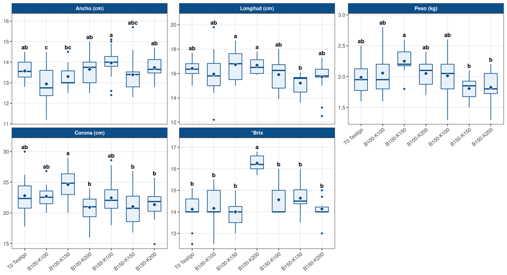

Figura 1: Figura 1. Distribución de las 112 plantas por tratamiento. Rombo: media; letras: Duncan (α = 0.05).

```r
largo <- d |>
  pivot_longer(all_of(names(vars)), names_to = "v", values_to = "valor") |>
  mutate(Variable = factor(vars[v], levels = vars))
letras <- largo |>
  group_by(Variable, Tratamiento) |>
  summarise(tope = max(valor), .groups = "drop") |>
  left_join(duncan |> mutate(Variable = factor(Variable, levels = vars),
                             Tratamiento = factor(Tratamiento, levels = orden)),
            by = c("Variable", "Tratamiento"))

ggplot(largo, aes(Tratamiento, valor)) +
  geom_boxplot(fill = "#e8f1fa", colour = "#0b4f8a", width = 0.6, outlier.size = 1) +
  stat_summary(fun = mean, geom = "point", shape = 23, size = 2.4, fill = "#0b4f8a", colour = "white") +
  geom_text(data = letras, aes(y = tope, label = letra), vjust = -0.6, size = 3.4, fontface = "bold") +
  scale_y_continuous(expand = expansion(mult = c(0.05, 0.15))) +
  facet_wrap(~ Variable, scales = "free_y", ncol = 3) +
  labs(x = NULL, y = NULL) +
  theme_bw(base_size = 11) +
  theme(axis.text.x = element_text(angle = 40, hjust = 1),
        strip.background = element_rect(fill = "#0b4f8a"),
        strip.text = element_text(colour = "white", face = "bold"),
        panel.grid.minor = element_blank())
```

**Ver código R**

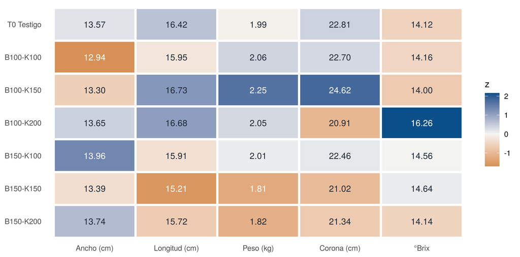

Figura 2: Figura 2. Perfil de los tratamientos: media de cada variable estandarizada (z). Azul intenso = valor más alto entre tratamientos.

```r
perfil <- duncan |>
  group_by(Variable) |>
  mutate(z = (media - mean(media)) / sd(media)) |>
  ungroup() |>
  mutate(Tratamiento = factor(Tratamiento, levels = rev(orden)),
         Variable = factor(Variable, levels = vars))

ggplot(perfil, aes(Variable, Tratamiento, fill = z)) +
  geom_tile(colour = "white", linewidth = 1.2) +
  geom_text(aes(label = sprintf("%.2f", media), colour = abs(z) > 1.2), size = 3.6) +
  scale_fill_gradient2(low = "#c9772b", mid = "#f4f4f2", high = "#0b4f8a", midpoint = 0, name = "z") +
  scale_colour_manual(values = c(`TRUE` = "white", `FALSE` = "#1f2937"), guide = "none") +
  labs(x = NULL, y = NULL) +
  theme_minimal(base_size = 11) +
  theme(panel.grid = element_blank())
```

## Análisis multivariado

**Ver código R**

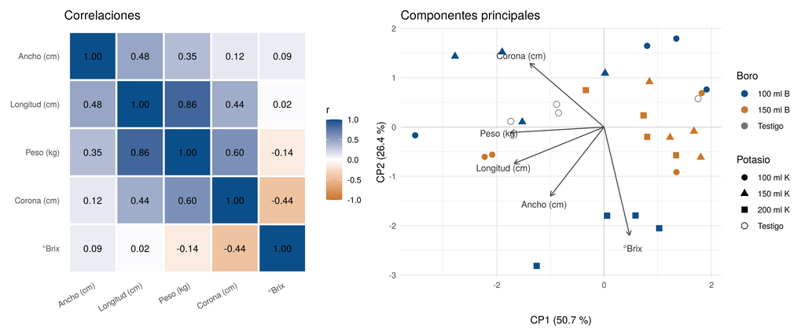

Figura 3: Figura 3. Izquierda: correlación de Pearson entre variables (28 parcelas). Derecha: análisis de componentes principales; puntos = parcelas, flechas = variables.

```r
library(patchwork)
X <- parcelas |> select(ends_with("_media"))
names(X) <- vars

cor_df <- as.data.frame(as.table(cor(X))) |>
  mutate(Var1 = factor(Var1, levels = vars), Var2 = factor(Var2, levels = rev(vars)))
g1 <- ggplot(cor_df, aes(Var1, Var2, fill = Freq)) +
  geom_tile(colour = "white", linewidth = 1) +
  geom_text(aes(label = sprintf("%.2f", Freq)), size = 3.6) +
  scale_fill_gradient2(low = "#c9772b", mid = "white", high = "#0b4f8a", limits = c(-1, 1), name = "r") +
  labs(x = NULL, y = NULL, title = "Correlaciones") +
  theme_minimal(base_size = 11) +
  theme(axis.text.x = element_text(angle = 30, hjust = 1), panel.grid = element_blank())

pca <- prcomp(X, scale. = TRUE)
expl <- round(100 * pca$sdev^2 / sum(pca$sdev^2), 1)
pts <- data.frame(pca$x[, 1:2],
                  Boro = ifelse(parcelas$Boro_ml == 0, "Testigo", paste(parcelas$Boro_ml, "ml B")),
                  Potasio = ifelse(parcelas$Potasio_ml == 0, "Testigo", paste(parcelas$Potasio_ml, "ml K")))
fl  <- data.frame(pca$rotation[, 1:2] * 3, var = rownames(pca$rotation))
g2 <- ggplot(pts, aes(PC1, PC2)) +
  geom_hline(yintercept = 0, colour = "grey85") + geom_vline(xintercept = 0, colour = "grey85") +
  geom_point(aes(colour = Boro, shape = Potasio), size = 2.8) +
  geom_segment(data = fl, aes(0, 0, xend = PC1, yend = PC2),
               arrow = arrow(length = unit(0.2, "cm")), colour = "grey30") +
  geom_text(data = fl, aes(PC1 * 1.12, PC2 * 1.12, label = var), colour = "grey20", size = 3.4) +
  scale_colour_manual(values = c("Testigo" = "grey45", "100 ml B" = "#0b4f8a", "150 ml B" = "#c9772b")) +
  scale_shape_manual(values = c("Testigo" = 1, "100 ml K" = 16, "150 ml K" = 17, "200 ml K" = 15)) +
  labs(x = paste0("CP1 (", expl[1], " %)"), y = paste0("CP2 (", expl[2], " %)"),
       title = "Componentes principales", colour = "Boro", shape = "Potasio") +
  theme_minimal(base_size = 11)

g1 + g2 + plot_layout(widths = c(1, 1.3))
```

## Conclusiones

- **Ancho (cm):** tratamientos significativos (p = 0.024); interacción B × K significativa (p = 0.030). Mayor media: B150-K100 (13.96, grupo a); testigo: 13.57 (grupo ab).
- **Longitud (cm):** tratamientos no significativos (p = 0.202); interacción B × K no significativa (p = 0.258). Mayor media: B100-K150 (16.73, grupo a); testigo: 16.42 (grupo ab).
- **Peso (kg):** tratamientos significativos (p = 0.038); interacción B × K no significativa (p = 0.106). Mayor media: B100-K150 (2.25, grupo a); testigo: 1.99 (grupo ab).
- **Corona (cm):** tratamientos significativos (p = 0.041); interacción B × K significativa (p = 0.041). Mayor media: B100-K150 (24.62, grupo a); testigo: 22.81 (grupo ab).
- **°Brix:** tratamientos significativos (p < 0.001); interacción B × K significativa (p < 0.001). Mayor media: B100-K200 (16.26, grupo a); testigo: 14.12 (grupo b).
- El peso del fruto depende sobre todo de su longitud (r = 0.86) y no del °Brix (r = -0.14): un tratamiento puede aumentar el dulzor sin cambiar el tamaño del fruto.

Datos: Chacón Huamaní, D. (2019). *Boro y potasio en post inducción de Ananas comosus L. Merr var. Golden MD-2 en Río Negro*. UNCP. http://hdl.handle.net/20.500.12894/5378